# MS4S09 ASSIGNMENT - AMAZON BOOK REVIEW ANALYSIS (30074879)

Gabriel Obot

19/02/2024

# Task A – Text Mining

### Load the neccesary libraries

```r
libraries <- c("tm", "tidytext", "ggplot2", "wordcloud", "syuzhet", "dplyr", "tibble", "textstem", "textdata", "tidyr", "Matrix", "topicmodels", "stringr", "reshape2", "LDAvis", "jsonlite")

#install.packages(libraries)

for (lib in libraries) {
  library(lib, character.only=TRUE) #Library takes function names without quotes, character only must be used in a loop of this kind.
}
```

```
## For information on available language packages for 'koRpus', run
##
##   available.koRpus.lang()
##
## and see ?install.koRpus.lang()
```

```r
library(tibble)
```

```r
library(dplyr)
```

### Load the data to a data frame and print summary and dimension

```r
filepath <- 'C:\\Users\\Gabriel Obot\\Desktop\\R-Data mining course work\\MS4S09_CW_Book_Reviews.csv'
df <- as_tibble(read.csv(filepath, stringsAsFactors = FALSE)) # Since we have text data we do not want this read as a factor
print(summary(df))
```

```
##     Title             Book_Price     Reviewer_id            Rating
##  Length:59296       Min.   :  1.00   Length:59296       Min.   :1.000
##  Class :character   1st Qu.: 10.36   Class :character   1st Qu.:4.000
##  Mode  :character   Median : 14.15   Mode  :character   Median :5.000
##                     Mean   : 20.81                      Mean   :4.231
##                     3rd Qu.: 22.99                      3rd Qu.:5.000
##                     Max.   :995.00                      Max.   :5.000
##       Time           Review_title       Review_text        Found_helpful_ratio
##  Min.   :8.688e+08   Length:59296       Length:59296       Min.   :0.0000
##  1st Qu.:1.087e+09   Class :character   Class :character   1st Qu.:0.0000
##  Median :1.169e+09   Mode  :character   Mode  :character   Median :0.6667
##  Mean   :1.173e+09                                         Mean   :0.5491
##  3rd Qu.:1.279e+09                                         3rd Qu.:1.0000
##  Max.   :1.362e+09                                         Max.   :1.0000
##   Publisher         First_author          Genre
##  Length:59296       Length:59296       Length:59296
##  Class :character   Class :character   Class :character
##  Mode  :character   Mode  :character   Mode  :character
##
##
##
```

### Inspect data

```r
print(head(df))
```

```
## # A tibble: 6 × 11
##   Title            Book_Price Reviewer_id Rating   Time Review_title Review_text
##   <chr>                 <dbl> <chr>        <int>  <int> <chr>        <chr>
## 1 In Six Days: Wh…      10.2  APD7XINUVG…      4 9.99e8 Solid testi… "Working f…
## 2 Lord Jim              15.6  AITANZIKX8…      5 9.16e8 &quot;You d… "A terrifi…
## 3 White Socks Only       5.16 AYB19RB36G…      4 1.34e9 White Socks… "As I open…
## 4 The Secret of t…      15.0  A1BOLCK0Q5…      5 1.28e9 great!       "Excellent…
## 5 Left to Tell: D…      17.5  A3WKJ88K78…      5 1.36e9 Great Book   "This book…
## 6 Don't Make Me T…      20.9  A1E6I4IPWW…      5 1.20e9 Don't think… "Excellent…
## # ℹ 4 more variables: Found_helpful_ratio <dbl>, Publisher <chr>,
## #   First_author <chr>, Genre <chr>
```

### Select relevant Data

```r
# Select the desired columns
df<- df %>%
  select(Title, Book_Price, Reviewer_id, Rating, Review_title,
         Review_text, Found_helpful_ratio, Publisher, First_author, Genre)

df <- na.omit(df) # Removes all rows containing null values


df$Review_no <- 1:nrow(df)

dim(df)
```

```
## [1] 59296    11
```

### Count number of reviews by Title and sort

```r
Title_counts <- count(df,Title, sort=TRUE) # Count number of reviews by Title and sort
head(Title_counts) # Print top 5 most reviewed Titles
```

```
## # A tibble: 6 × 2
##   Title                                                                        n
##   <chr>                                                                    <int>
## 1 Eldest (Inheritance, Book 2)                                               276
## 2 Great Expectations                                                         263
## 3 Hannibal                                                                   258
## 4 Good to Great                                                              203
## 5 The Five Love Languages: The Secret to Love that Lasts                     201
## 6 Love & Respect: The Love She Most Desires; The Respect He Desperately N…   144
```

### Sample the data to use for analysis: print the summary and dimension

```r
set.seed(1)

# Take sample of 5 Titles
sample_index<- sample(length(unique(df$Title)), 10) #Sample (Size of population, Size of sample), returns index for sample

# Take Title at index defined previously
sampled_titles <- unique(df$Title)[sample_index]

# Select only rows where restaurant is one of sampled_titles
df <- df %>%
  filter(Title %in% sampled_titles)

print(summary(df))
```

```
##     Title             Book_Price     Reviewer_id            Rating
##  Length:19          Min.   :  1.49   Length:19          Min.   :2.000
##  Class :character   1st Qu.: 11.61   Class :character   1st Qu.:3.500
##  Mode  :character   Median : 33.56   Mode  :character   Median :5.000
##                     Mean   : 33.54                      Mean   :4.211
##                     3rd Qu.: 42.00                      3rd Qu.:5.000
##                     Max.   :105.02                      Max.   :5.000
##  Review_title       Review_text        Found_helpful_ratio  Publisher
##  Length:19          Length:19          Min.   :0.0000      Length:19
##  Class :character   Class :character   1st Qu.:0.5000      Class :character
##  Mode  :character   Mode  :character   Median :0.8571      Mode  :character
##                                        Mean   :0.6736
##                                        3rd Qu.:0.9643
##                                        Max.   :1.0000
##  First_author          Genre             Review_no
##  Length:19          Length:19          Min.   : 5886
##  Class :character   Class :character   1st Qu.:13764
##  Mode  :character   Mode  :character   Median :28857
##                                        Mean   :28378
##                                        3rd Qu.:34436
##                                        Max.   :58202
```

```r
print(dim(df))
```

```
## [1] 19 11
```

### Tokenize Review_text

```r
# Tokenize word column by word
library(tidytext)
word_tokenized_data <- df %>%
  unnest_tokens(output = word, input = "Review_text", token = "words", to_lower = TRUE)

# Tokenize word column to bigrams
bigram_tokenized_data <- df %>%
  unnest_tokens(output = bigram, input = "Review_text", token = "ngrams", n=2, to_lower = TRUE)
```

### Plot of top 10 words before cleaning of the review_text columns shows that

### the top words are mostly stop words

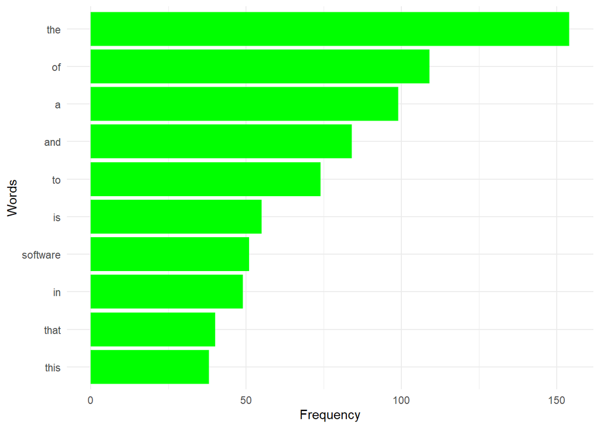

```r
library(ggplot2)

word_counts <- word_tokenized_data %>%
  count(word, sort = TRUE)

ggplot(word_counts[1:10, ], aes(x = reorder(word, n), y = n)) +
  geom_col(fill = "green") +
  labs(x = "Words", y = "Frequency") +
  coord_flip() +
  theme_minimal()
```

### Word cloud before cleaning review_text shows that the stop words

### are mostly stop words

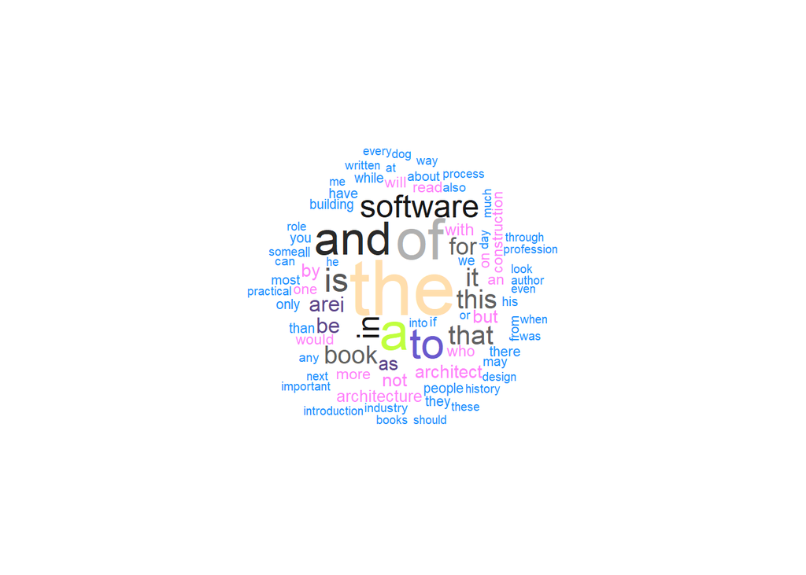

```r
library(wordcloud)

set.seed(1)
wordcloud(words = word_counts$word, freq = word_counts$n, min.freq = 5, random.order=FALSE, random.color=FALSE, colors = sample(colors(), size = 15))
```

### Plot of top 10 bigrams also shows that bigrams consist of stop words

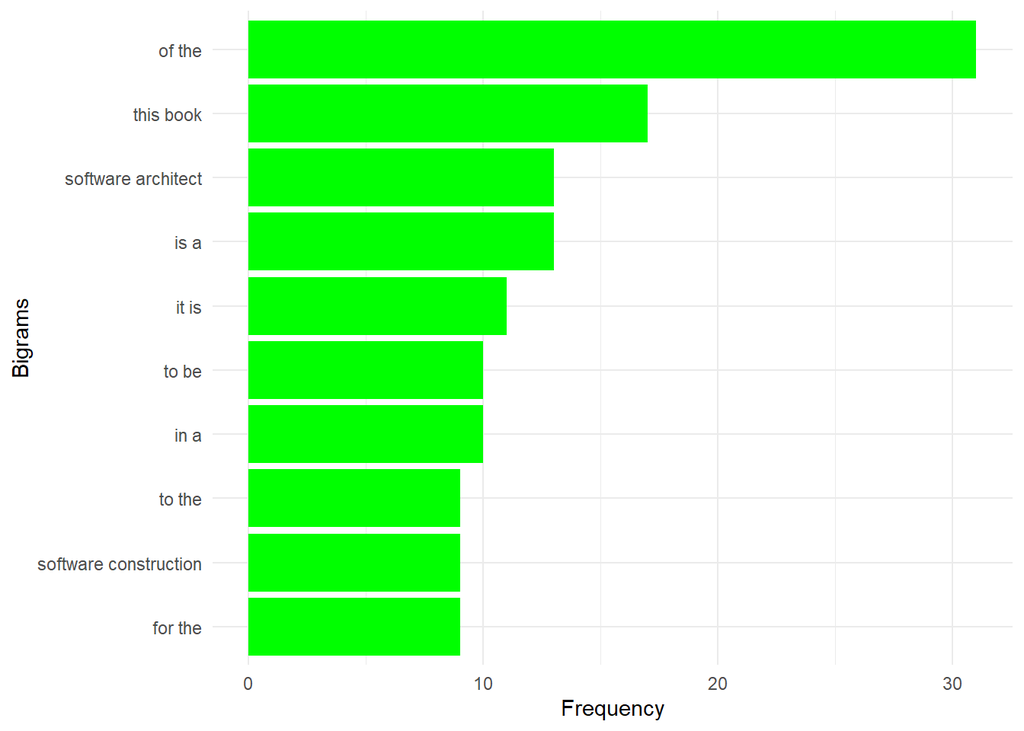

```r
# Plot of top 10 bigrams
bigram_counts <- bigram_tokenized_data %>%
  count(bigram, sort = TRUE)

ggplot(bigram_counts[1:10, ], aes(x = reorder(bigram, n), y = n)) +
  geom_col(fill = "green") +
  labs(x = "Bigrams", y = "Frequency") +
  coord_flip() +
  theme_minimal()
```

```r
install.packages("textstem")
library(textstem)
```

```r
library(magrittr)
```

#### Cleaning Data

```r
# Load necessary packages
library(dplyr)
library(tidytext)
library(textstem)

# Clean tokens and lemmatize
clean_tokens <- word_tokenized_data %>%
  anti_join(stop_words, by = "word") %>%
  mutate(word = gsub("[^a-zA-Z ]", "", word),  # Remove special characters and numbers
         word = na_if(word, "")) %>%  # Replace empty strings with NA
  filter(!is.na(word)) %>%  # Remove NA values
  mutate(word = lemmatize_words(word))  # Lemmatize text

# Untokenize and retokenize to get cleaned bigrams
untokenized_data <- clean_tokens %>%
  group_by(Review_no) %>%
  summarize(clean_review = paste(word, collapse = " ")) %>%
  inner_join(df, by = "Review_no")  # Adjust column selection if necessary

# Create bigrams from cleaned text
clean_bigrams <- untokenized_data %>%
  unnest_tokens(output = bigram, input = clean_review, token = "ngrams", n = 2, to_lower = TRUE)
```

#### Top 10 Words After Cleaning

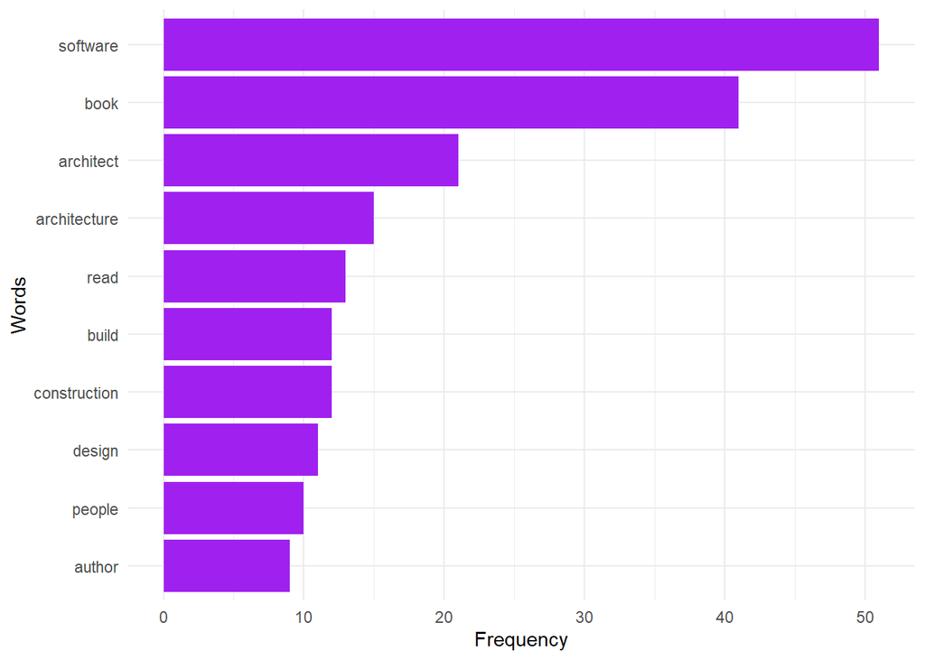

```r
word_counts <- clean_tokens %>%
  count(word, sort = TRUE)

top_words <- top_n(word_counts,10,n)$word

filtered_word_counts <- filter(word_counts, word %in% top_words)
filtered_word_counts$word <- factor(filtered_word_counts$word, levels = top_words[length(top_words):1])

ggplot(filtered_word_counts, aes(x = reorder(word, n), y = n)) +
  geom_col(fill = "Purple") +
  labs(x = "Words", y = "Frequency") +
  coord_flip() +
  theme_minimal()
```

#### Top 10 Bigrams After Cleaning

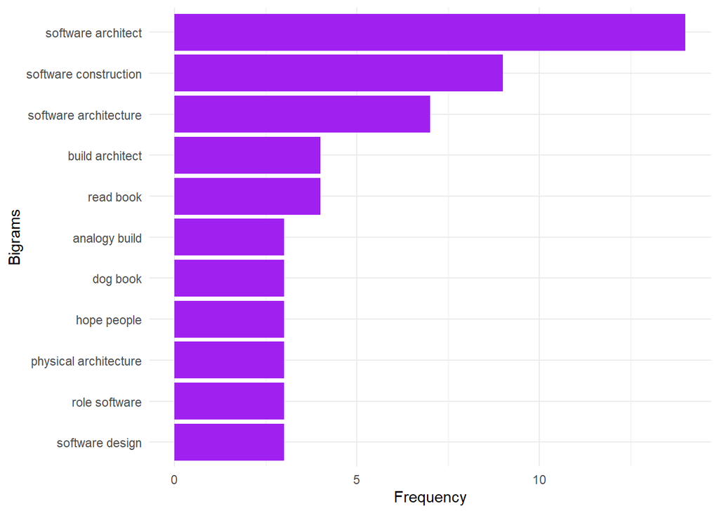

```r
bigram_counts <- clean_bigrams %>%
  count(bigram, sort = TRUE)

top_bigrams <- top_n(bigram_counts,10,n)$bigram

filtered_bigram_counts <- filter(bigram_counts, bigram %in% top_bigrams)
filtered_bigram_counts$bigram <- factor(filtered_bigram_counts$bigram, levels = top_bigrams[length(top_bigrams):1])

ggplot(filtered_bigram_counts, aes(x = reorder(bigram, n), y = n)) +
  geom_col(fill = "purple") +
  labs(x = "Bigrams", y = "Frequency") +
  coord_flip() +
  theme_minimal()
```

#### Plot the top 10 words by Title

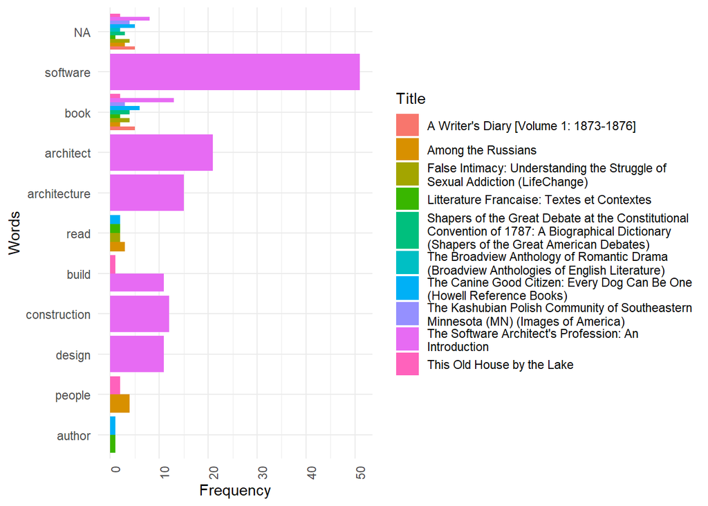

```r
# Function to get top words for each title
top_words_per_title <- clean_tokens %>%
  group_by(Title, word) %>%
  count() %>%
  arrange(Title, desc(n)) %>%
  group_by(Title) %>%
  slice_head(n = 10) %>%
  ungroup()

# Ensure 'word' is a factor with the desired levels
top_words_per_title$word <- factor(top_words_per_title$word, levels = rev(top_words))

# Shorten Title if Necessary
top_words_per_title$Short_Title <- stringr::str_wrap(top_words_per_title$Title, width = 50)

# Plotting
ggplot(data = top_words_per_title, aes(x = word, y = n, fill = Short_Title)) +
  geom_col(position = "dodge") +
  labs(x = "Words", y = "Frequency", fill = "Title") +
  coord_flip() +
  theme_minimal() +
  theme(axis.text.x = element_text(angle = 90, hjust = 1)) +
  scale_fill_discrete(name = "Title")  # Rename fill legend
```

#### Top 10 Bigrams by Title

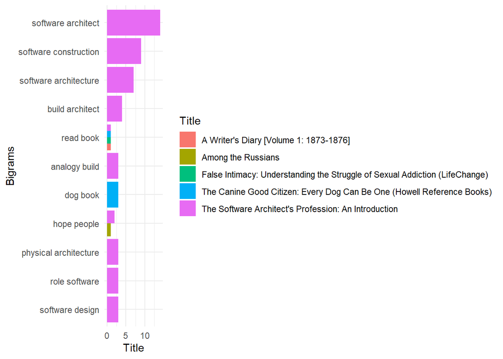

```r
# Grouped Bigrams
top_bigrams <- top_n(bigram_counts,10,n)$bigram

grouped_count <- group_by(clean_bigrams, Title) %>%
  count(bigram) %>%
  filter(bigram %in% top_bigrams)

grouped_count$bigram <- factor(grouped_count$bigram, levels = top_bigrams[length(top_bigrams):1])

ggplot(data = grouped_count, aes(x = bigram, y = n, fill = Title)) +
  geom_col(position = "dodge") +
  labs(x = "Bigrams", y = "Title", fill = "Title") +
  coord_flip() +
  theme_minimal()
```

#Creating Word Cloud

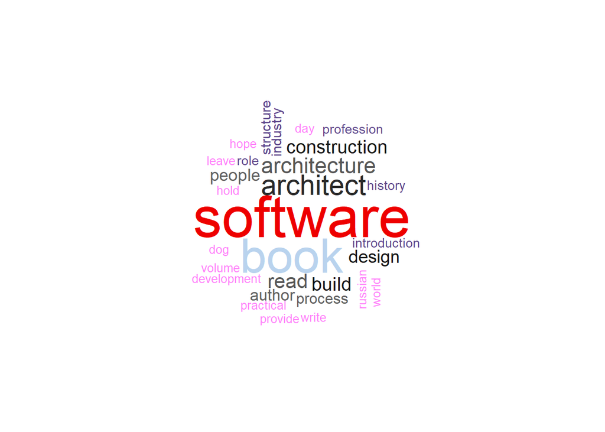

```r
library(wordcloud)

set.seed(1)
wordcloud(words = word_counts$word, freq = word_counts$n, min.freq = 5, random.order=FALSE, random.color=FALSE, colors = sample(colors(), size = 20))
```

# Task 2: Sentiment Analysis

In this task, we explored different ways to understand the emotions behind text using three techniques: AFINN, NRC, and Bing lexicons. AFINN gives scores to words based on their emotional tone, helping us classify sentiment. The NRC lexicon, developed by experts, categorizes words into emotional groups, giving us a detailed view of sentiment. Meanwhile, Bing lexicon is simpler, just labeling words as positive or negative.  
By using these techniques together, we gained valuable tools to understand emotions in text better. It’s like having a powerful emotional radar to navigate through written content, making it easier to understand what people are feeling.

#### The bing Lexicon

```r
bing_sentiments <- get_sentiments("bing")

summary(bing_sentiments)
```

```
##      word            sentiment
##  Length:6786        Length:6786
##  Class :character   Class :character
##  Mode  :character   Mode  :character
```

```r
print(unique(bing_sentiments$sentiment))
```

```
## [1] "negative" "positive"
```

```r
set.seed(1)
bing_sentiments[sample(nrow(bing_sentiments), 5),]
```

```
## # A tibble: 5 × 2
##   word           sentiment
##   <chr>          <chr>
## 1 conspiratorial negative
## 2 prosperity     positive
## 3 exorbitantance negative
## 4 repugn         negative
## 5 disable        negative
```

#### AFINN lexicon

```r
afinn_sentiments <- get_sentiments("afinn")

summary(afinn_sentiments)
```

```
##      word               value
##  Length:2477        Min.   :-5.0000
##  Class :character   1st Qu.:-2.0000
##  Mode  :character   Median :-2.0000
##                     Mean   :-0.5894
##                     3rd Qu.: 2.0000
##                     Max.   : 5.0000
```

```r
set.seed(1)
afinn_sentiments[sample(nrow(afinn_sentiments), 5),]
```

```
## # A tibble: 5 × 2
##   word           value
##   <chr>          <dbl>
## 1 frantic           -1
## 2 disappointing     -2
## 3 sullen            -2
## 4 fabulous           4
## 5 misinformation    -2
```

#### The NRC lexicon

```r
nrc_sentiments <- get_sentiments("nrc")

summary(nrc_sentiments)
```

```
##      word            sentiment
##  Length:13872       Length:13872
##  Class :character   Class :character
##  Mode  :character   Mode  :character
```

```r
head(nrc_sentiments)
```

```
## # A tibble: 6 × 2
##   word      sentiment
##   <chr>     <chr>
## 1 abacus    trust
## 2 abandon   fear
## 3 abandon   negative
## 4 abandon   sadness
## 5 abandoned anger
## 6 abandoned fear
```

```r
print(unique(nrc_sentiments$sentiment))
```

```
##  [1] "trust"        "fear"         "negative"     "sadness"      "anger"
##  [6] "surprise"     "positive"     "disgust"      "joy"          "anticipation"
```

## Applying bing lexicon

```r
 #Create dataset containing only words with associated sentiment & adds sentiment column.
sentiment_data <- clean_tokens %>%
  inner_join(get_sentiments("bing"), by = "word")

# Calculate Sentiment scores for each review
sentiment_score <- sentiment_data %>%
  group_by(Review_no) %>%
  summarize(bing_sentiment = sum(sentiment == "positive") - sum(sentiment == "negative"))

# Merge with df
df_with_sentiment = df %>%
  inner_join(sentiment_score, by = "Review_no")
```

#### worst reviews

```r
worst_reviews = df_with_sentiment[order(df_with_sentiment$bing_sentiment)[1],"Review_text"]

for (review in worst_reviews){
  print(review)
}
```

```
## [1] "This book is a compendium of 3-5 page biographies of each of the 55 delegates to the Constitutional Convention of 1787. It is a useful book full of good information, but that said, it is all information that is readily available in numerous on-line biographies of the Constitutional Delegates…
```

#### Best review

```r
best_reviews = df_with_sentiment[order(df_with_sentiment$bing_sentiment, decreasing = TRUE)[1],"Review_text"]

for (review in best_reviews){
  print(review)
}
```

```
## [1] "We are in an industry whereby progress can be effectively described by Moore's Law, stating that every 18 months, processing power doubles while cost holds constant. Telecommunications bandwidth and computer memory and storage capacity are experiencing a similar fate.Although we cannot say t…
```

#### Histogram of bing sentiment score

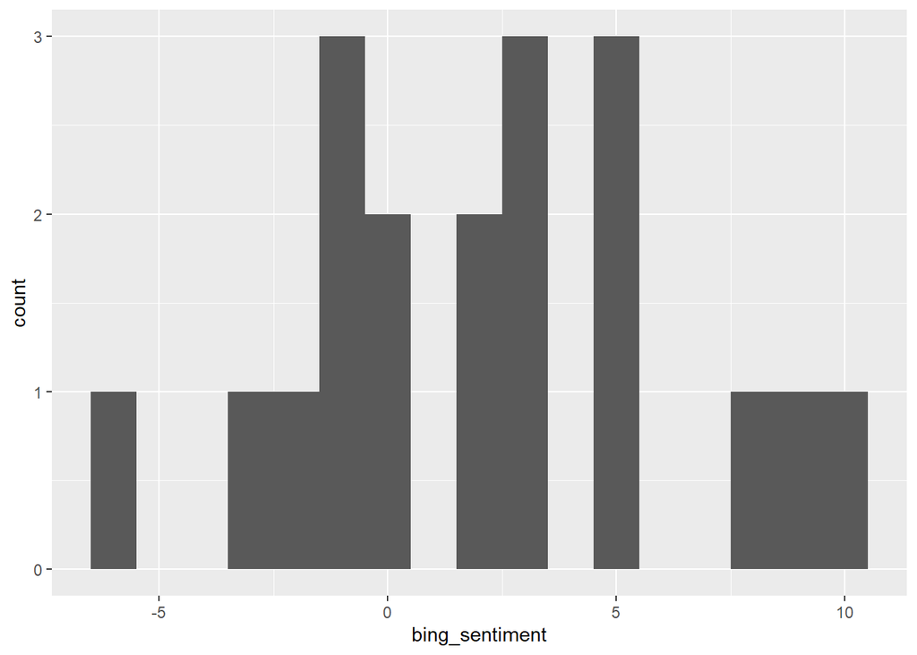

```r
# Histogram of sentiment scores
ggplot(df_with_sentiment, aes(x = bing_sentiment)) +
  geom_histogram(binwidth = 1)
```

#### Average Bing sentiment score by title

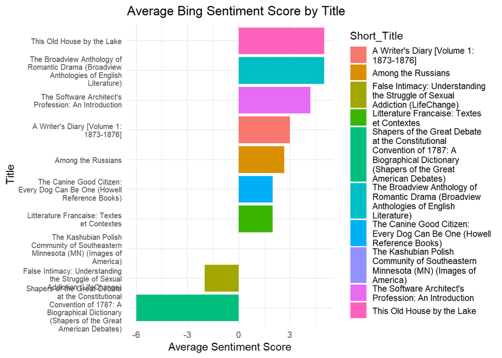

```r
# Load necessary libraries
library(ggplot2)
library(dplyr)
library(stringr)  # For str_wrap function



# Average Sentiment by Title
title_sentiment <- df_with_sentiment %>%
  group_by(Title) %>%
  summarize(Average_Bing_Sentiment = mean(bing_sentiment, na.rm = TRUE))

# Shorten titles
title_sentiment$Short_Title <- str_wrap(title_sentiment$Title, width = 29)  # Adjust width as needed

# Plotting with adjusted dimensions and shortened titles
ggplot(title_sentiment, aes(x = reorder(Short_Title, Average_Bing_Sentiment), y = Average_Bing_Sentiment, fill = Short_Title)) +
  geom_col() +
  coord_flip() +
  labs(title = "Average Bing Sentiment Score by Title", x = "Title", y = "Average Sentiment Score") +
  theme_minimal() +
  theme(axis.text.y = element_text(size = 7.5))  # Adjust the size of the axis text
```

#### dot plot of sentiment score vs rating

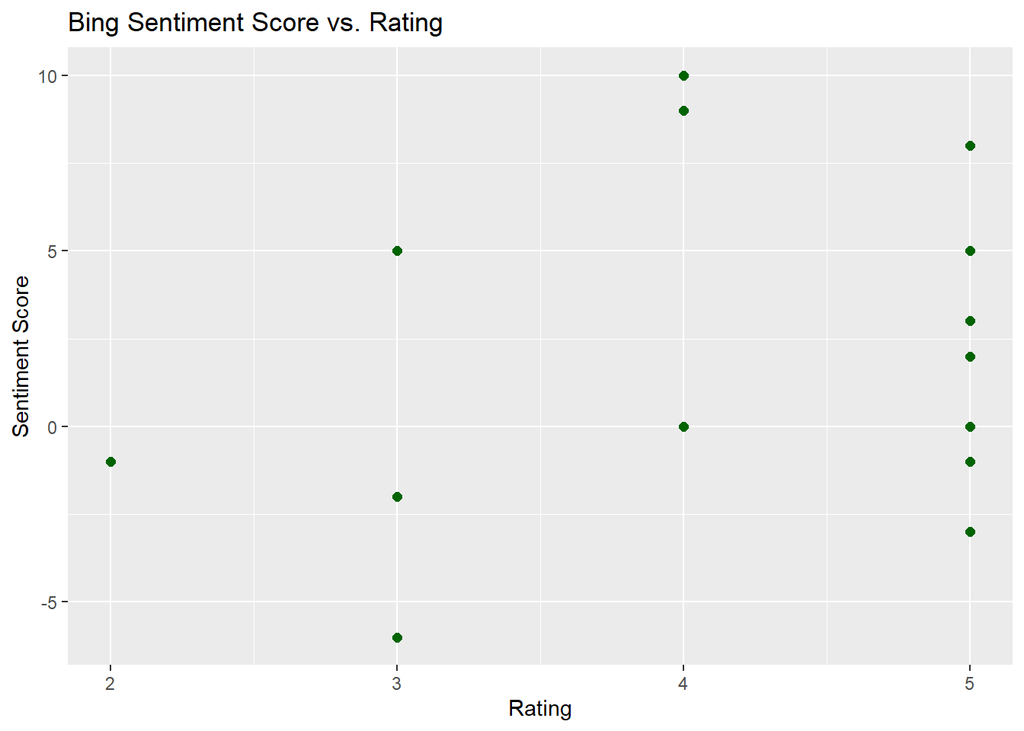

```r
# Plotting sentiment score vs. rating with increased dot size
ggplot(df_with_sentiment, aes(x = Rating, y = bing_sentiment)) +
  geom_point(color = "darkgreen", size = 2) +  # Increased dot size
  labs(title = "Bing Sentiment Score vs. Rating", x = "Rating", y = "Sentiment Score")
```

## Applying AFINN lexicon

```r
# Create dataset containing only words with associated sentiment & adds sentiment column.
sentiment_data <- clean_tokens %>%
  inner_join(get_sentiments("afinn"), by = "word")

# Calculate Sentiment scores for each review
sentiment_score <- sentiment_data %>%
  group_by(Review_no) %>%
  summarize(afinn_sentiment = sum(value))

# Merge with df
df_with_sentiment = df_with_sentiment %>%
  inner_join(sentiment_score, by = "Review_no")
```

# Worst review Afinn

```r
worst_reviews = df_with_sentiment[order(df_with_sentiment$afinn_sentiment)[1],"Review_text"]

for (review in worst_reviews){
  print(review)
}
```

```
## [1] "This is a book (actually the first volume of a 2-volume set) forDostoevsky aficianados. There is some very interesting and varied material in this large volume -- essays, imaginings, journalism, polemic, short stories, propoganda, rants, etc.. A kind of 'Fyodor Unwrapped.' It helps to have r…
```

#Best Review - Afinn

```r
best_reviews = df_with_sentiment[order(df_with_sentiment$afinn_sentiment, decreasing = TRUE)[1],"Review_text"]

for (review in best_reviews){
  print(review)
}
```

```
## [1] "We are in an industry whereby progress can be effectively described by Moore's Law, stating that every 18 months, processing power doubles while cost holds constant. Telecommunications bandwidth and computer memory and storage capacity are experiencing a similar fate.Although we cannot say t…
```

#### Histogram of sentiments score

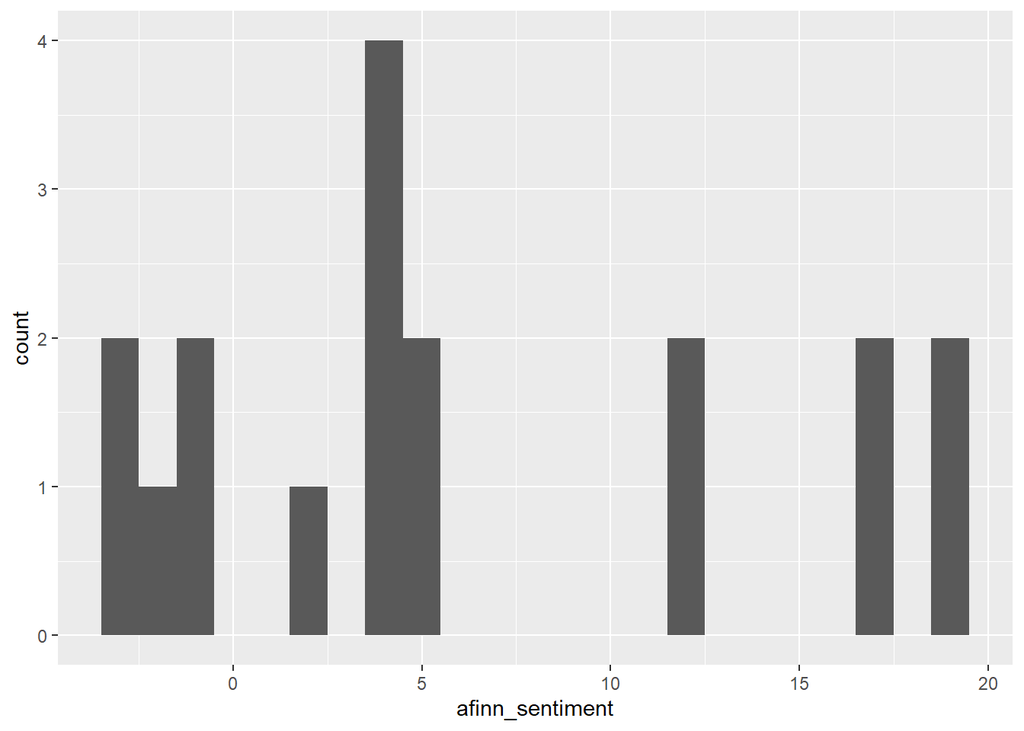

```r
# Histogram of sentiment scores
ggplot(df_with_sentiment, aes(x = afinn_sentiment)) +
  geom_histogram(binwidth = 1)
```

#### Average Sentiment by Title

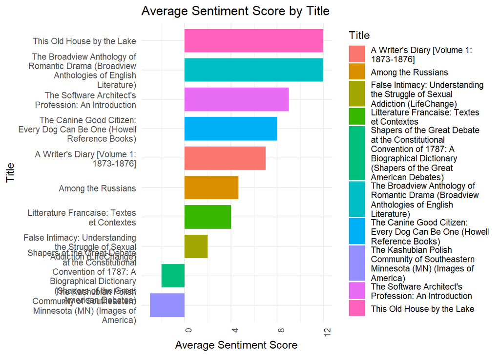

```r
# Load necessary libraries
library(ggplot2)
library(dplyr)
library(stringr)  # For str_wrap function



# Average Sentiment by Title
title_sentiment <- df_with_sentiment %>%
  group_by(Title) %>%
  summarize(Average_Afinn_Sentiment = mean(afinn_sentiment, na.rm = TRUE))

# Shorten titles
title_sentiment$Short_Title <- str_wrap(title_sentiment$Title, width = 29)  # Adjust width as needed

# Plotting with adjusted dimensions and shortened titles
ggplot(title_sentiment, aes(x = reorder(Short_Title, Average_Afinn_Sentiment), y = Average_Afinn_Sentiment, fill = Short_Title)) +
  geom_bar(stat = "identity", width = 0.8) +  # Adjust the width of the bars (increase from default 0.8)
  coord_flip() +
  labs(title = "Average Sentiment Score by Title", x = "Title", y = "Average Sentiment Score") +
  theme_minimal() +  # Change plot theme
  theme(axis.text.x = element_text(angle = 90, hjust = 1)) +  # Rotate x-axis labels vertically
  scale_fill_discrete(name = "Title")  # Rename fill legend
```

#### Average Sentiment Score by Title

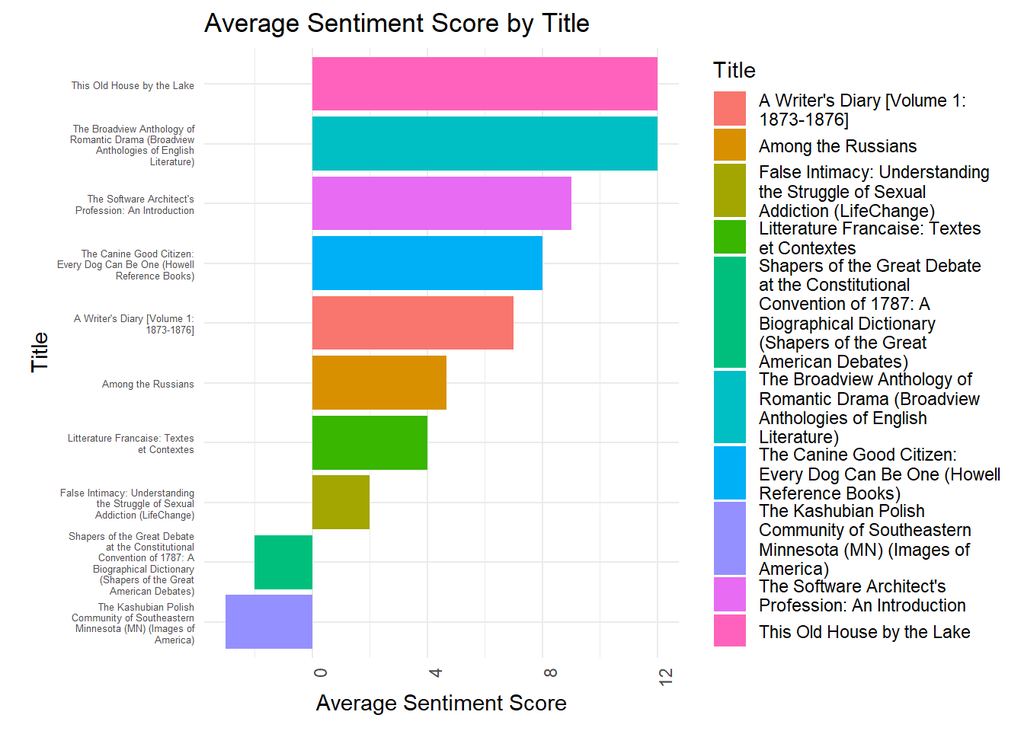

```r
# Load necessary libraries
library(ggplot2)
library(dplyr)
library(stringr)  # For str_wrap function



# Average Sentiment by Title
title_sentiment <- df_with_sentiment %>%
  group_by(Title) %>%
  summarize(Average_Afinn_Sentiment = mean(afinn_sentiment, na.rm = TRUE))

# Shorten titles
title_sentiment$Short_Title <- str_wrap(title_sentiment$Title, width = 29)  # Adjust width as needed

# Plotting with adjusted dimensions and shortened titles
ggplot(title_sentiment, aes(x = reorder(Short_Title, Average_Afinn_Sentiment), y = Average_Afinn_Sentiment, fill = Short_Title)) +
  geom_bar(stat = "identity", width = 0.9) +  # Adjust the width of the bars (increase from default 0.8)
  coord_flip() +
  labs(title = "Average Sentiment Score by Title", x = "Title", y = "Average Sentiment Score") +
  theme_minimal() +  # Change plot theme
  theme(axis.text.x = element_text(angle = 90, hjust = 1),  # Rotate x-axis labels vertically
        axis.text.y = element_text(size = 5),  # Adjust the size of y-axis labels
        plot.margin = margin(l = 15, r = 6, t = 6, b = 8)) +  # Expand the space for the y-axis label
  scale_fill_discrete(name = "Title")  # Rename fill legend
```

#### Box Plot of Afinn Sentiment vs Rating

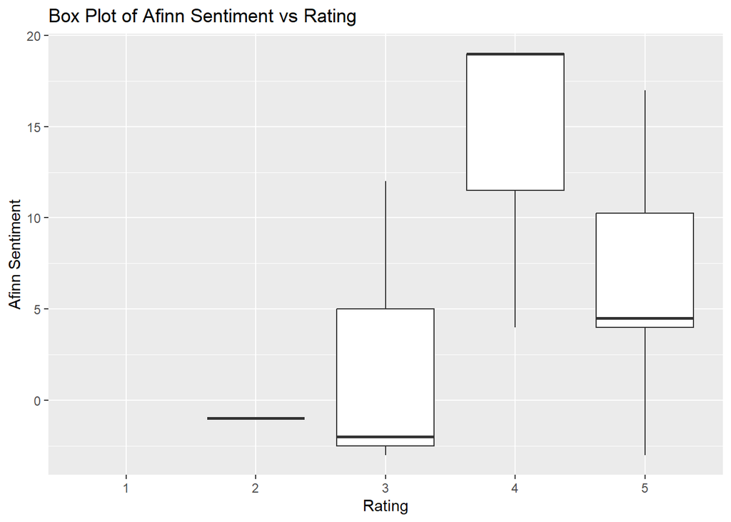

```r
# Convert Rating to a factor with all levels
df_with_sentiment$Rating <- factor(df_with_sentiment$Rating, levels = c(1, 2, 3, 4, 5))

ggplot(df_with_sentiment, aes(x = factor(Rating), y = afinn_sentiment)) +
  geom_boxplot() +
  labs(title = "Box Plot of Afinn Sentiment vs Rating", x = "Rating", y = "Afinn Sentiment") +
  scale_x_discrete(limits = c("1", "2", "3", "4", "5"))
```

#### Applying NRC lexicon

```r
# Suppress warning messages
suppressWarnings({
  # Create dataset containing only words with associated sentiment & adds sentiment column.
  emotion_data <- clean_tokens %>%
    inner_join(get_sentiments("nrc"), by = "word")
})
```

```r
library(tidyr)

# Calculate Sentiment scores for each review
emotion_count <- emotion_data %>%
  group_by(Review_no) %>%
  count(sentiment)

# Pivots data so that there is a column associated with each emotion
wide_emotion_data <- emotion_count %>%
  pivot_wider(names_from = sentiment, values_from = n, values_fill = list(n = 0))

# Merge with df
df_with_sentiment = df_with_sentiment %>%
  inner_join(wide_emotion_data, by = "Review_no")
```

```r
print(df_with_sentiment)
```

```
## # A tibble: 18 × 23
##    Title                  Book_Price Reviewer_id Rating Review_title Review_text
##    <chr>                       <dbl> <chr>       <fct>  <chr>        <chr>
##  1 The Canine Good Citiz…       1.49 A1HU6MPN7Z… 2      Not a lot o… "The notio…
##  2 The Software Architec…      33.6  A20TGKIX97… 4      Son, forget… "We are in…
##  3 The Canine Good Citiz…       1.49 A1Q2MQZIAE… 5      This book s… "I am a do…
##  4 The Software Architec…      33.6  A2MDOHH5TM… 2      Overpriced,… "While I r…
##  5 The Software Architec…      33.6  A1GEZYDTQC… 4      It had to b… "The Sewel…
##  6 Litterature Francaise…     105.   A3PWEGD7DM… 5      Just PERFECT "The book …
##  7 Shapers of the Great …      79.0  A23BNT7UYC… 3      A Useful bu… "This book…
##  8 False Intimacy: Under…      11.6  A29DK932WF… 5      Excellent i… "This book…
##  9 The Software Architec…      33.6  A20TGKIX97… 4      Software Ar… "We are in…
## 10 Among the Russians          11.7  A2B9ZVMW8X… 5      Excellent b… "This is a…
## 11 Among the Russians          11.7  A3R4756DJG… 5      A trip thro… "Written b…
## 12 A Writer's Diary [Vol…      42    A2VQ2AIHUY… 3      FYODOR UNWR… "This is a…
## 13 The Software Architec…      33.6  A11Y4YEORM… 5      A Needed In… "As a prog…
## 14 The Kashubian Polish …      17.2  A376QXJHF5… 5      You don't h… "This book…
## 15 Among the Russians          80.0  A2B9ZVMW8X… 5      Excellent b… "This is a…
## 16 This Old House by the…       5.1  A3GAR8V786… 3      living inte… "the gifts…
## 17 The Broadview Antholo…      50.0  A3PEG5N5GP… 5      Great editi… "This Broa…
## 18 A Writer's Diary [Vol…      42    A3T2HDSSLR… 5      deeply flaw… "This book…
## # ℹ 17 more variables: Found_helpful_ratio <dbl>, Publisher <chr>,
## #   First_author <chr>, Genre <chr>, Review_no <int>, bing_sentiment <int>,
## #   afinn_sentiment <dbl>, anger <int>, anticipation <int>, joy <int>,
## #   negative <int>, positive <int>, sadness <int>, trust <int>, disgust <int>,
## #   fear <int>, surprise <int>
```

```r
long_df <- df_with_sentiment %>%
  pivot_longer(cols = c("joy", "positive", "trust", "anticipation", "surprise", "sadness", "negative", "anger", "disgust", "fear"),
               names_to = "Emotion",
               values_to = "Intensity")

emotion_scores <- long_df %>%
  group_by(Title, Emotion) %>%
  summarize(avg_intensity = mean(Intensity))
```

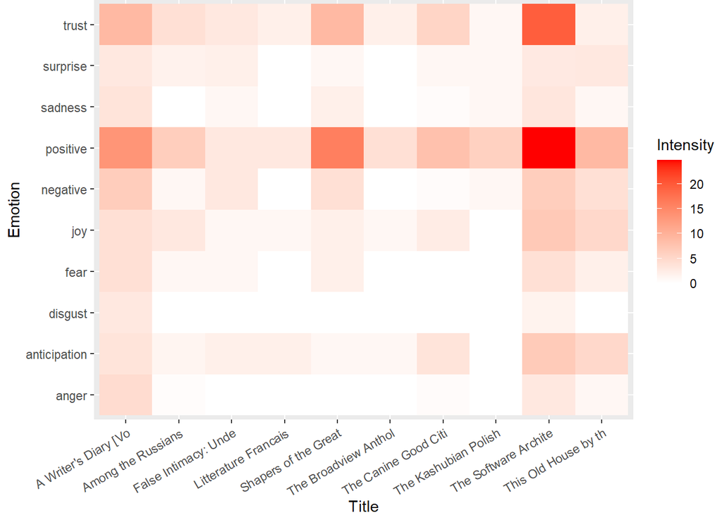

```r
# Load necessary libraries
library(ggplot2)
library(stringr)



# Shorten the variable names
short_titles <- str_sub(emotion_scores$Title, 1, 20)  # Extract first 20 characters of each title

# Plot the heatmap
ggplot(emotion_scores, aes(x = str_wrap(short_titles, width = 20), y = Emotion, fill = avg_intensity)) +
  geom_tile() +  # Creates the heatmap tiles
  scale_fill_gradient2(low = "blue", high = "red") +  # Adjust colors
  labs(x = "Title", y = "Emotion", fill = "Intensity") +
  theme(axis.text.x = element_text(angle = 30, hjust = 1, vjust = 1, lineheight = 1),
        plot.margin = margin(l = 5))  # Adjust left margin to create more space
```

### Conclusions drawn from my findings

Based on the analysis of sentiment scores from Bing, AFINN, and NRC lexicons for a selection of reviews, several conclusions can be drawn:

Bing Sentiment Analysis:

The Bing lexicon provided contrasting sentiment scores for different reviews. The worst review exhibited negative sentiment with a score of -6, while the best review displayed positive sentiment. Additionally, the average sentiment score varied across different titles, indicating fluctuations in the overall sentiment expressed in the reviews. AFINN Sentiment Analysis:

NRC Lexicon Analysis: The NRC lexicon analysis revealed specific emotions associated with different titles. For instance, the title “The Software Architecture” elicited high levels of positive emotion, while “Trust” was also prominent, indicating a positive emotional tone associated with this title. This suggests that NRC lexicon analysis can provide insight into the emotional nuances of text data beyond simple positive or negative sentiment. In conclusion, the sentiment analysis conducted using Bing, AFINN, and NRC lexicons revealed diverse emotional expressions within the analyzed texts. Each lexicon provided unique insights into the sentiment and emotional content of the reviews, demonstrating the importance of selecting appropriate lexicons based on the specific objectives of the analysis. Additionally, the comparison between different lexicons highlighted the importance of considering multiple perspectives to gain a comprehensive understanding of sentiment in textual data.

# TASK C: Topic Modelling

### Load the important Libraries

```r
libraries <- c("Matrix", "topicmodels", "stringr", "reshape2", "LDAvis", "jsonlite")

# Comment out after first execution
#install.packages(libraries)

for (lib in libraries) {
  library(lib, character.only=TRUE) #Library takes function names without quotes, character only must be used in a loop of this kind.
}
```

### DATA SELECTION AND SAMPLING

In this case, I will load a fresh data to a new data frame to do this Topic modelling analysis

```r
library(tibble)

book_reviews <- as_tibble(read.csv(filepath, stringsAsFactors = FALSE))

print(summary(book_reviews))
```

```
##     Title             Book_Price     Reviewer_id            Rating
##  Length:59296       Min.   :  1.00   Length:59296       Min.   :1.000
##  Class :character   1st Qu.: 10.36   Class :character   1st Qu.:4.000
##  Mode  :character   Median : 14.15   Mode  :character   Median :5.000
##                     Mean   : 20.81                      Mean   :4.231
##                     3rd Qu.: 22.99                      3rd Qu.:5.000
##                     Max.   :995.00                      Max.   :5.000
##       Time           Review_title       Review_text        Found_helpful_ratio
##  Min.   :8.688e+08   Length:59296       Length:59296       Min.   :0.0000
##  1st Qu.:1.087e+09   Class :character   Class :character   1st Qu.:0.0000
##  Median :1.169e+09   Mode  :character   Mode  :character   Median :0.6667
##  Mean   :1.173e+09                                         Mean   :0.5491
##  3rd Qu.:1.279e+09                                         3rd Qu.:1.0000
##  Max.   :1.362e+09                                         Max.   :1.0000
##   Publisher         First_author          Genre
##  Length:59296       Length:59296       Length:59296
##  Class :character   Class :character   Class :character
##  Mode  :character   Mode  :character   Mode  :character
##
##
##
```

### Find the min, max and average length of review text

### This will enable me decide the number of words to chose to determine the sample to select

```r
# Tokenize the review text into words
library(stringr)
library(dplyr)

book_reviews <- book_reviews %>%
  mutate(num_words = str_count(Review_text, "\\w+"))  # Count the number of words in each review text

# Find minimum, maximum, and average number of words
min_words <- min(book_reviews$num_words, na.rm = TRUE)
max_words <- max(book_reviews$num_words, na.rm = TRUE)
avg_words <- mean(book_reviews$num_words, na.rm = TRUE)

# Print the results
print(paste("Minimum number of words:", min_words))
```

```
## [1] "Minimum number of words: 1"
```

```r
print(paste("Maximum number of words:", max_words))
```

```
## [1] "Maximum number of words: 5520"
```

```r
print(paste("Average number of words:", avg_words))
```

```
## [1] "Average number of words: 149.808975310308"
```

```r
# Selecting relevant features
book_reviews <- book_reviews %>%
  select(c("Title", "Review_text", "Review_title", "Genre")) %>%
  filter(str_count(Review_text) >= 200 & str_count(Review_text) <= 400)

# Replace values of "unknown" in Genre with NA
book_reviews$Genre <- na_if(book_reviews$Genre, "unknown")

# Remove rows with missing values
book_reviews <- na.omit(book_reviews)

# Add a column for book numbers
book_reviews$book_no <- 1:nrow(book_reviews)

# Sample 1000 rows if there are more than 1000
if(nrow(book_reviews) > 1000) {
  set.seed(1)
  book_reviews <- sample_n(book_reviews, 1000)
}
```

As seen below there are 57 unique genres in the sampled data

```r
unique_genres <- unique(book_reviews$Genre)
num_unique_genres <- length(unique_genres)
print(num_unique_genres)
```

```
## [1] 57
```

```r
head(book_reviews)
```

```
## # A tibble: 6 × 5
##   Title                                   Review_text Review_title Genre book_no
##   <chr>                                   <chr>       <chr>        <chr>   <int>
## 1 Hachiko Waits                           I PURCHASE… HACHIKO WAI… Juve…    1017
## 2 I Feel Bad About My Neck: And Other Th… ...and des… I haven't l… Humor    8004
## 3 French in Action : A Beginning Course … If you are… The best fr… Fore…    4775
## 4 Twenty One Days to a Trained Dog        Bought the… Yeah right   Pets    10369
## 5 Country Property Dirt Cheap: How I Fou… Ralph Turn… Solid advice Busi…   13218
## 6 Famous Last Words, Fond Farewells, Dea… I would re… Enjoyable b… Refe…    9725
```

### Ceate term document matrix

```r
library(tm)


# Convert text column to corpus
corpus <- VCorpus(VectorSource(book_reviews$Review_text))

# Apply cleaning
corpus <- tm_map(corpus, content_transformer(tolower)) %>%
  tm_map(removePunctuation) %>%
  tm_map(removeNumbers) %>%
  tm_map(removeWords, stopwords("en")) %>%
  tm_map(stripWhitespace) %>%
  tm_map(stemDocument)

# Convert to a term document matrix
tdm <- TermDocumentMatrix(corpus, control = list(wordLengths = c(3, 15)))

tdm_matrix <- as.matrix(tdm)
```

### check the dimnension of the tdm_matrix

```r
dim(tdm_matrix)
```

```
## [1] 5160 1000
```

### plot the frequency distribution

```r
library(ggplot2)


term_frequencies <- rowSums(tdm_matrix)

# Create a data frame for plotting
term_frequency_df <- data.frame(term = names(term_frequencies), frequency = term_frequencies)

# Sort the data frame by frequency in descending order and select the top 10
top_terms <- term_frequency_df %>%
  arrange(desc(frequency)) %>%
  head(10)

# Display the top 10 terms
print(top_terms)
```

```
##        term frequency
## book   book      1368
## read   read       535
## one     one       260
## great great       220
## love   love       193
## like   like       173
## good   good       170
## will   will       160
## stori stori       142
## time   time       142
```

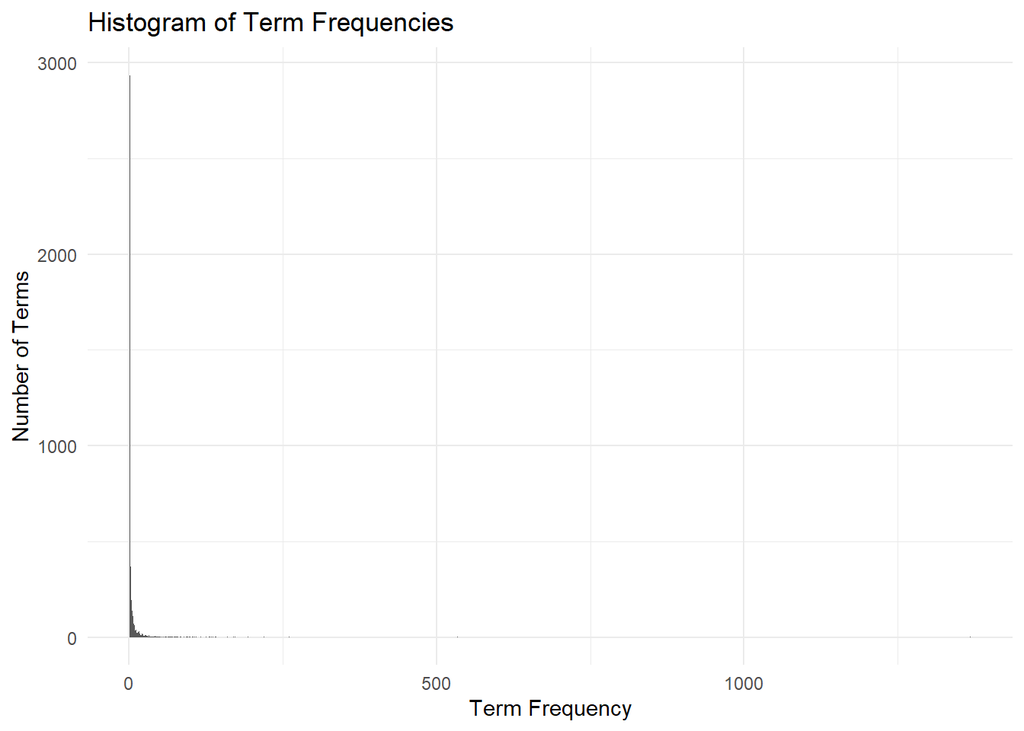

```r
# Create the histogram
ggplot(term_frequency_df, aes(x = frequency)) +
  geom_histogram(binwidth = 1) +
  labs(title = "Histogram of Term Frequencies",
       x = "Term Frequency",
       y = "Number of Terms") +
  theme_minimal()
```

### compute the frequent terms in the created tdm_matrix

```r
# Compute term frequencies
term_frequencies <- rowSums(tdm_matrix)

# Create a data frame for plotting
term_frequency_df <- data.frame(term = names(term_frequencies), frequency = term_frequencies)

# Sort the data frame by frequency in descending order and select the top terms
top_terms <- term_frequency_df %>%
  arrange(desc(frequency)) %>%
  head(10)  # Adjust the number of top terms as needed

# Display the top terms
print(top_terms)
```

```
##        term frequency
## book   book      1368
## read   read       535
## one     one       260
## great great       220
## love   love       193
## like   like       173
## good   good       170
## will   will       160
## stori stori       142
## time   time       142
```

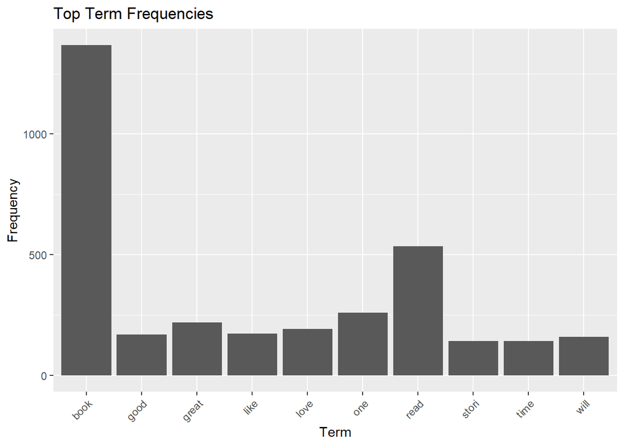

```r
# Create a histogram
ggplot(top_terms, aes(x = term, y = frequency)) +
  geom_bar(stat = "identity") +
  labs(title = "Top Term Frequencies", x = "Term", y = "Frequency") +
  theme(axis.text.x = element_text(angle = 45, hjust = 1))
```

```r
# Compute term frequencies
term_frequencies <- rowSums(tdm_matrix)

# Create a data frame for plotting
term_frequency_df <- data.frame(term = names(term_frequencies), frequency = term_frequencies)

# Sort the data frame by frequency in descending order and select the top terms
top_terms <- term_frequency_df %>%
  arrange(desc(frequency)) %>%
  head(10)  # Adjust the number of top terms as needed

# Display the top terms
print(top_terms)
```

```
##        term frequency
## book   book      1368
## read   read       535
## one     one       260
## great great       220
## love   love       193
## like   like       173
## good   good       170
## will   will       160
## stori stori       142
## time   time       142
```

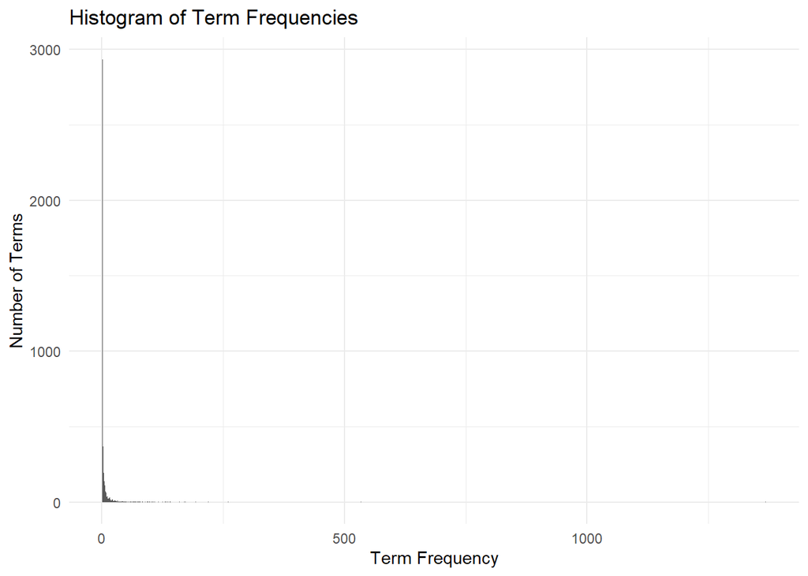

```r
# Create the histogram
ggplot(term_frequency_df, aes(x = frequency)) +
  geom_histogram(binwidth = 1) +
  labs(title = "Histogram of Term Frequencies",
       x = "Term Frequency",
       y = "Number of Terms") +
  theme_minimal()
```

### Selecting terms to remove

```r
#Find terms that appear in more than 10% of documents
frequent_terms <- findFreqTerms(tdm, lowfreq = 0.1 * ncol(tdm_matrix))

#Find terms that appear in less than 1% of documents
rare_terms <- findFreqTerms(tdm, highfreq =  0.01 * ncol(tdm_matrix))


print("Frequent Terms")
```

```
## [1] "Frequent Terms"
```

```r
print(frequent_terms)
```

```
##  [1] "book"      "can"       "get"       "good"      "great"     "help"
##  [7] "interest"  "just"      "like"      "look"      "love"      "make"
## [13] "mani"      "one"       "read"      "realli"    "recommend" "stori"
## [19] "time"      "use"       "want"      "well"      "will"
```

```r
print("First 20 Infrequent Terms")
```

```
## [1] "First 20 Infrequent Terms"
```

```r
print(rare_terms[1:20])
```

```
##  [1] "aarhus"        "aaron"         "abandon"       "abduct"
##  [5] "abil"          "abour"         "aboveaverag"   "abroad"
##  [9] "abrupt"        "absenc"        "absorb"        "absurd"
## [13] "abund"         "abundanceamaz" "abundancein"   "abundanceit"
## [17] "aburrido"      "abus"          "acadamia"      "academ"
```

```r
to_keep <- c("book",
             "good",
             "great",
             "like",
             "love",
             "read",
             "recommend",
             "story",
             "well",
             "will")

to_remove <- frequent_terms[!frequent_terms %in% to_keep]
```

##Removing Terms

```r
filtered_tdm_matrix <- tdm_matrix[!rownames(tdm_matrix)  %in% to_remove,]
filtered_tdm_matrix <- filtered_tdm_matrix[!rownames(filtered_tdm_matrix) %in% rare_terms,]

#Remove 0 sum columns from tdm


#calculate col sums
column_sums <- colSums(filtered_tdm_matrix)

#Identify col that are all zeros
zero_columns <- which(column_sums == 0)

#remove these columns
if(length(zero_columns)>0) {
  #Remove these columns
  filtered_tdm_matrix <- filtered_tdm_matrix [, -zero_columns]
} else {
  #If no columns are all zeros, just use the original matrix
  Print("No zero columns in TDM MAtrix")
  }
```

### frequency of terms after cleaning

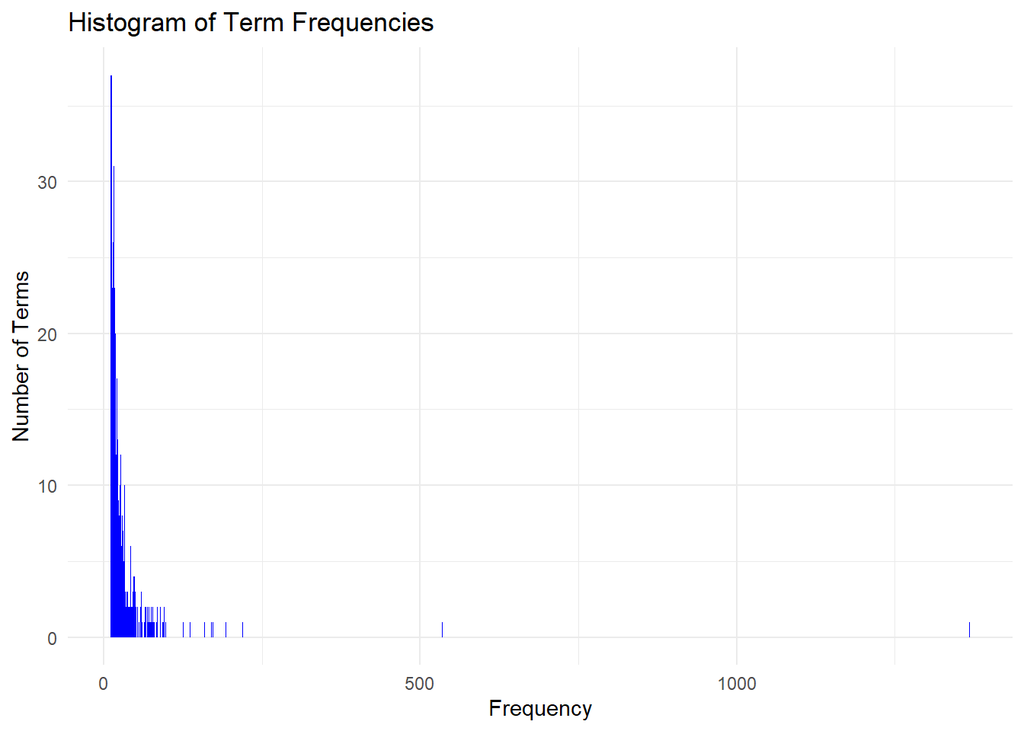

```r
# Compute term frequencies
term_frequencies <- rowSums(filtered_tdm_matrix)

# Create a data frame for plotting
term_frequency_df <- data.frame(term = names(term_frequencies), frequency = term_frequencies)

# Create the histogram
ggplot(term_frequency_df, aes(x = frequency)) +
  geom_histogram(binwidth = 1, fill = "blue") +
  labs(title = "Histogram of Term Frequencies",
       x = "Frequency",
       y = "Number of Terms") +
  theme_minimal()
```

### Applying LDA

```r
library(topicmodels)

dtm <- t(filtered_tdm_matrix)
lda_model <- LDA(dtm, k = 7)
```

### Visualize Topics

```r
set.seed(1)

topics <- tidy(lda_model, matrix = "beta")
topics
```

```
## # A tibble: 3,213 × 3
##    topic term        beta
##    <int> <chr>      <dbl>
##  1     1 abl     0.00216
##  2     2 abl     0.00276
##  3     3 abl     0.000419
##  4     4 abl     0.000198
##  5     5 abl     0.000522
##  6     6 abl     0.00302
##  7     7 abl     0.00131
##  8     1 absolut 0.000858
##  9     2 absolut 0.00102
## 10     3 absolut 0.000412
## # ℹ 3,203 more rows
```

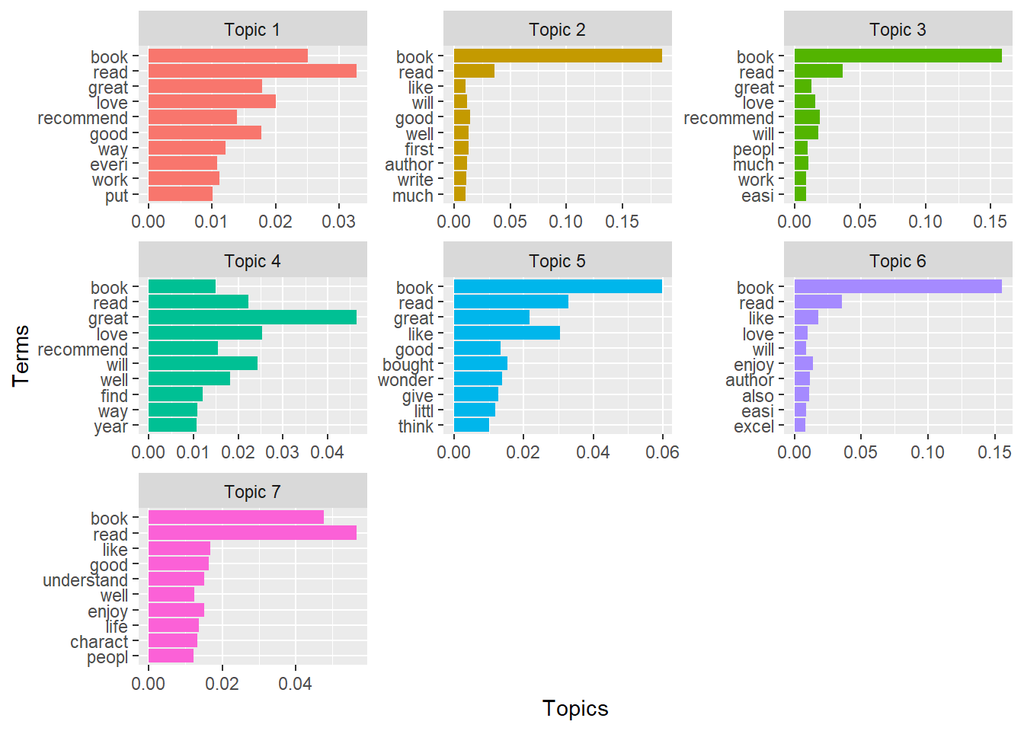

```r
top_terms <- topics %>%
  group_by(topic) %>%
  top_n(10, beta) %>%
  ungroup() %>%
  arrange(topic, -beta)

top_terms %>%
  ggplot(aes(x = reorder(term, beta), y = beta, fill = factor(topic))) +
  geom_col(show.legend = FALSE) +
  facet_wrap(~ topic, scales = "free", labeller = labeller(topic = function(x) paste("Topic", x))) +
  coord_flip() +
  labs(x = "Terms", y = "Topics")  # Add labels for axes
```

### Choosing the appropriate number of topics (k) in topic modeling is an important

### decision, as it directly impacts the interpretability and granularity of the resulting topics.

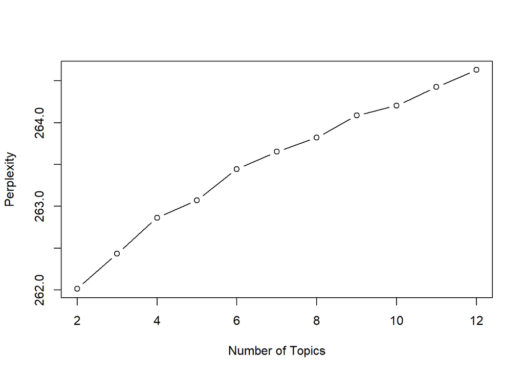

```r
range_k <- seq(2, 12, by = 1)  # Adjust the range as needed
perplexities <- sapply(range_k, function(k) {
  model <- LDA(dtm, k = k, control = list(seed = 1))
  perplexity(model)
})

# Plotting perplexities
plot(range_k, perplexities, type = "b", xlab = "Number of Topics", ylab = "Perplexity")
```